# COMPARATIVA ERTES DURANTE PERIODOS CRISIS FINANCIERA / COVID-19 EN LA COMUNIDAD VALENCIANA

Grupo laboratorio: María del Rocio Vidal Manzano | Javier Martínez Germán | Óscar Jiménez Osuna.

31/01/2021

```r
library(knitr)

knitr::opts_chunk$set(echo = TRUE)
```

*Fuente* : https://dadesobertes.gva.es/es/dataset/tra-eres-ertes-v2-2021

## ATRIBUTOS

FECHA_SOLICITUD timestamp Fecha de solicitud

PROVINCIA text  
Provincia en la que la empresa tiene su sede social

MUNICIPIO text  
Municipio en el que la empresa tiene su sede social. Consulte la autoridad laboral ante la que presenta la solicitud para saber en qué provincia se encuentra el centro laboral afectado

SECTOR text  
Sector al que pertenecen las empresas

SECTOR_FACT numeric Sector al que pertenecen las empresas factorizado:

DESC_CNAE text  
Actividad económica

CAUSA text  
Causa de la solicitud del expediente de regulación

TOTAL_TRAB_EXT numeric Total de personas trabajadoras para las cuales se ha solicitado extinción

TOTAL_TRAB_RED numeric Total de personas trabajadoras para las cuales se ha solicitado reducción

TOTAL_TRAB_SUS numeric Total de personas trabajadoras para las cuales se ha solicitado suspensión

### Carga de datos.

```r
#install.packages("dplyr")
library(dplyr)
library(tidyverse)
library(readxl)
df <- read_excel("C:/datos.xlsx")
head(df)
```

```
## # A tibble: 6 x 13
##   FECHA_SOLICITUD     PROVINCIA MUNICIPIO SECTOR_FACT SECTOR AUTORIDAD_LABOR~
##   <dttm>              <chr>     <chr>           <dbl> <chr>  <chr>
## 1 2021-01-27 00:00:00 Alicante~ Campello~           5 SERVI~ S.T. ALICANTE
## 2 2021-01-27 00:00:00 Alicante~ Orihuela            5 SERVI~ S.T. ALICANTE
## 3 2021-01-27 00:00:00 Alicante~ Teulada             5 SERVI~ S.T. ALICANTE
## 4 2021-01-27 00:00:00 Valencia~ Sagunt/S~           5 SERVI~ DT VALENCIA
## 5 2021-01-26 00:00:00 Alicante~ Atzúbia,~           5 SERVI~ S.T. ALICANTE
## 6 2021-01-26 00:00:00 Alicante~ Albatera            5 SERVI~ S.T. ALICANTE
## # ... with 7 more variables: COD_CNAE <dbl>, DESC_CNAE <chr>, CAUSA <chr>,
## #   TOTAL_TRAB_EXT <dbl>, TOTAL_TRAB_RED <dbl>, TOTAL_TRAB_SUS <dbl>,
## #   TOTAL_TRAB <dbl>
```

### Resumen de los estadísticos.

```r
summary(df)
```

```
##  FECHA_SOLICITUD                PROVINCIA          MUNICIPIO
##  Min.   :2000-11-07 00:00:00   Length:102237      Length:102237
##  1st Qu.:2016-06-17 00:00:00   Class :character   Class :character
##  Median :2020-03-25 00:00:00   Mode  :character   Mode  :character
##  Mean   :2017-12-04 22:27:58
##  3rd Qu.:2020-04-01 00:00:00
##  Max.   :2021-01-27 00:00:00
##   SECTOR_FACT       SECTOR          AUTORIDAD_LABORAL     COD_CNAE
##  Min.   :3.000   Length:102237      Length:102237      Min.   :   0
##  1st Qu.:4.000   Class :character   Class :character   1st Qu.:4322
##  Median :5.000   Mode  :character   Mode  :character   Median :5221
##  Mean   :4.722                                         Mean   :5304
##  3rd Qu.:5.000                                         3rd Qu.:6209
##  Max.   :5.000                                         Max.   :9900
##   DESC_CNAE            CAUSA           TOTAL_TRAB_EXT     TOTAL_TRAB_RED
##  Length:102237      Length:102237      Min.   :   0.000   Min.   :   0.000
##  Class :character   Class :character   1st Qu.:   0.000   1st Qu.:   0.000
##  Mode  :character   Mode  :character   Median :   0.000   Median :   0.000
##                                        Mean   :   1.496   Mean   :   1.111
##                                        3rd Qu.:   0.000   3rd Qu.:   0.000
##                                        Max.   :9200.000   Max.   :1280.000
##  TOTAL_TRAB_SUS        TOTAL_TRAB
##  Min.   :    0.000   Min.   :    0.0
##  1st Qu.:    1.000   1st Qu.:    1.0
##  Median :    2.000   Median :    3.0
##  Mean   :    7.488   Mean   :   10.1
##  3rd Qu.:    5.000   3rd Qu.:    7.0
##  Max.   :11964.000   Max.   :11964.0
```

### Comprobación cantidad de valores nulos.

```r
sum(is.na(df))
```

```
## [1] 368
```

### Eliminamos los valores nulos y comprobamos que no queda ninguno.

```r
df<-na.omit(df)
sum(is.na(df))
```

```
## [1] 0
```

### Cantidad de filas y columnas.

```r
dim(df)
```

```
## [1] 101869     13
```

### Ordenamos por fecha.

```r
df<-df[order(df$FECHA_SOLICITUD),]
head(df)
```

```
## # A tibble: 6 x 13
##   FECHA_SOLICITUD     PROVINCIA MUNICIPIO SECTOR_FACT SECTOR AUTORIDAD_LABOR~
##   <dttm>              <chr>     <chr>           <dbl> <chr>  <chr>
## 1 2000-11-16 00:00:00 Alicante~ Alacant/~           4 INDUS~ D.G.
## 2 2000-11-22 00:00:00 Valencia~ Museros             4 INDUS~ DT VALENCIA
## 3 2000-11-27 00:00:00 Valencia~ Almussaf~           4 INDUS~ D.G.
## 4 2000-11-28 00:00:00 Alicante~ Ibi                 5 SERVI~ S.T. ALICANTE
## 5 2000-12-12 00:00:00 Alicante~ Aspe                4 INDUS~ S.T. ALICANTE
## 6 2000-12-20 00:00:00 Castelló~ Vinaròs             4 INDUS~ S.T. CASTELLON
## # ... with 7 more variables: COD_CNAE <dbl>, DESC_CNAE <chr>, CAUSA <chr>,
## #   TOTAL_TRAB_EXT <dbl>, TOTAL_TRAB_RED <dbl>, TOTAL_TRAB_SUS <dbl>,
## #   TOTAL_TRAB <dbl>
```

### Filtramos por año los periodos del 2008 al 2014 (crisis financiera) y del 2020 hasta la fecha actual (crisis del COVID).

```r
df_2008 = filter(df, FECHA_SOLICITUD >= "2008-01-01" & FECHA_SOLICITUD <= "2014-12-31")
head(df_2008)
```

```
## # A tibble: 6 x 13
##   FECHA_SOLICITUD     PROVINCIA MUNICIPIO SECTOR_FACT SECTOR AUTORIDAD_LABOR~
##   <dttm>              <chr>     <chr>           <dbl> <chr>  <chr>
## 1 2008-01-01 00:00:00 Alicante~ Petrer              5 SERVI~ S.T. ALICANTE
## 2 2008-01-02 00:00:00 Valencia~ Benetúss~           4 INDUS~ DT VALENCIA
## 3 2008-01-04 00:00:00 Valencia~ València            4 INDUS~ MINISTERIO
## 4 2008-01-04 00:00:00 Valencia~ València            5 SERVI~ DT VALENCIA
## 5 2008-01-07 00:00:00 Valencia~ Albaida             4 INDUS~ DT VALENCIA
## 6 2008-01-07 00:00:00 Valencia~ València            4 CONST~ DT VALENCIA
## # ... with 7 more variables: COD_CNAE <dbl>, DESC_CNAE <chr>, CAUSA <chr>,
## #   TOTAL_TRAB_EXT <dbl>, TOTAL_TRAB_RED <dbl>, TOTAL_TRAB_SUS <dbl>,
## #   TOTAL_TRAB <dbl>
```

```r
df_2020 = filter(df, FECHA_SOLICITUD >= "2020-03-01" & FECHA_SOLICITUD <= "2021-01-26")
head(df_2020)
```

```
## # A tibble: 6 x 13
##   FECHA_SOLICITUD     PROVINCIA MUNICIPIO SECTOR_FACT SECTOR AUTORIDAD_LABOR~
##   <dttm>              <chr>     <chr>           <dbl> <chr>  <chr>
## 1 2020-03-03 00:00:00 Alicante~ Elx/Elche           4 INDUS~ CONCURSAL
## 2 2020-03-03 00:00:00 Alicante~ Elx/Elche           5 SERVI~ S.T. ALICANTE
## 3 2020-03-03 00:00:00 Valencia~ Moixent/~           4 INDUS~ DT VALENCIA
## 4 2020-03-03 00:00:00 Valencia~ València            4 CONST~ DT VALENCIA
## 5 2020-03-03 00:00:00 Valencia~ València            5 SERVI~ DT VALENCIA
## 6 2020-03-04 00:00:00 Alicante~ Sant Joa~           5 SERVI~ S.T. ALICANTE
## # ... with 7 more variables: COD_CNAE <dbl>, DESC_CNAE <chr>, CAUSA <chr>,
## #   TOTAL_TRAB_EXT <dbl>, TOTAL_TRAB_RED <dbl>, TOTAL_TRAB_SUS <dbl>,
## #   TOTAL_TRAB <dbl>
```

```r
sum(df_2008$TOTAL_TRAB_SUS)
```

```
## [1] 223714
```

```r
sum(df_2020$TOTAL_TRAB_SUS)
```

```
## [1] 422495
```

```r
length(unique(subset((df_2008$FECHA_SOLICITUD), df_2008$TOTAL_TRAB_SUS==0)))
```

```
## [1] 1678
```

```r
length(unique(subset((df_2020$FECHA_SOLICITUD), df_2020$TOTAL_TRAB_SUS==0)))
```

```
## [1] 268
```

# Modelo relacional basado en la estadística relacional básica.

## Medidas de tendencia central (medias y medianas).

### Moda trabajadores suspendidos.

```r
moda_2008<-c(names(which(table(df_2008$TOTAL_TRAB_SUS)==max(table(df_2008$TOTAL_TRAB_SUS)))))

moda_2020<-c(names(which(table(df_2020$TOTAL_TRAB_SUS)==max(table(df_2020$TOTAL_TRAB_SUS)))))

modas<-data.frame(moda_2008,moda_2020, row.names = c("TOTAL_TRAB_SUS" ))
modas
```

```
##                moda_2008 moda_2020
## TOTAL_TRAB_SUS         0         1
```

### Moda trabajadores extinguidos.

```r
moda2_2008<-c(names(which(table(df_2008$TOTAL_TRAB_EXT)==max(table(df_2008$TOTAL_TRAB_EXT)))))

moda2_2020<-c(names(which(table(df_2020$TOTAL_TRAB_EXT)==max(table(df_2020$TOTAL_TRAB_EXT)))))

modas2<-data.frame(moda2_2008,moda2_2020, row.names = c("TOTAL_TRAB_EXT" ))
modas2
```

```
##                moda2_2008 moda2_2020
## TOTAL_TRAB_EXT          0          0
```

### Moda trabajadores reducidos.

```r
moda3_2008<-c(names(which(table(df_2008$TOTAL_TRAB_RED)==max(table(df_2008$TOTAL_TRAB_RED)))))

moda3_2020<-c(names(which(table(df_2020$TOTAL_TRAB_RED)==max(table(df_2020$TOTAL_TRAB_RED)))))

modas3<-data.frame(moda3_2008,moda3_2020, row.names = c("TOTAL_TRAB_RED" ))
modas3
```

```
##                moda3_2008 moda3_2020
## TOTAL_TRAB_RED          0          0
```

### Media trabajadores suspendidos.

```r
medias_2008<-c(mean(df_2008$TOTAL_TRAB_SUS))
medias_2020<-c(mean(df_2020$TOTAL_TRAB_SUS))
medias<-data.frame(medias_2008,medias_2020, row.names = c("TOTAL_TRAB_SUS" ))
medias
```

```
##                medias_2008 medias_2020
## TOTAL_TRAB_SUS    10.62623    5.696459
```

### Media trabajadores extinguidos.

```r
medias2_2008<-c(mean(df_2008$TOTAL_TRAB_EXT))
medias2_2020<-c(mean(df_2020$TOTAL_TRAB_EXT))
medias2<-data.frame(medias2_2008,medias2_2020, row.names = c("TOTAL_TRAB_EXT" ))
medias2
```

```
##                medias2_2008 medias2_2020
## TOTAL_TRAB_EXT     3.794186   0.05652033
```

### Media trabajadores reducidos.

```r
medias3_2008<-c(mean(df_2008$TOTAL_TRAB_RED))
medias3_2020<-c(mean(df_2020$TOTAL_TRAB_RED))
medias3<-data.frame(medias3_2008,medias3_2020, row.names = c("TOTAL_TRAB_RED" ))
medias3
```

```
##                medias3_2008 medias3_2020
## TOTAL_TRAB_RED     2.261293    0.7677165
```

### Mediana trabajadores suspendidos.

```r
median_2008<-c(median(df_2008$TOTAL_TRAB_SUS))
median_2020<-c(median(df_2020$TOTAL_TRAB_SUS))
medianas<-data.frame(median_2008,median_2020, row.names = c("TOTAL_TRAB_SUS" ))
medianas
```

```
##                median_2008 median_2020
## TOTAL_TRAB_SUS           1           2
```

### Mediana trabajadores extinguidos.

```r
median2_2008<-c(median(df_2008$TOTAL_TRAB_EXT))
median2_2020<-c(median(df_2020$TOTAL_TRAB_EXT))
medianas2<-data.frame(median2_2008,median2_2020, row.names = c("TOTAL_TRAB_EXT" ))
medianas2
```

```
##                median2_2008 median2_2020
## TOTAL_TRAB_EXT            0            0
```

### Mediana trabajadores reducidos.

```r
median3_2008<-c(median(df_2008$TOTAL_TRAB_RED))
median3_2020<-c(median(df_2020$TOTAL_TRAB_RED))
medianas3<-data.frame(median3_2008,median3_2020, row.names = c("TOTAL_TRAB_RED" ))
medianas3
```

```
##                median3_2008 median3_2020
## TOTAL_TRAB_RED            0            0
```

### Medidas de posición.

```r
Q25_2008<-c(quantile(df_2008$TOTAL_TRAB_SUS, 0.25))
Q25_2020<-c(quantile(df_2020$TOTAL_TRAB_SUS, 0.25))
Q5_2008<-c(quantile(df_2008$TOTAL_TRAB_SUS, 0.5))

Q5_2020<-c(quantile(df_2020$TOTAL_TRAB_SUS, 0.5))
Q75_2008<-c(quantile(df_2008$TOTAL_TRAB_SUS, 0.75))
Q75_2020<-c(quantile(df_2020$TOTAL_TRAB_SUS, 0.75))

Q<-data.frame(Q25_2008,Q25_2020,Q5_2008,Q5_2020, Q75_2008, Q75_2020, row.names = c( "TOTAL_TRAB_SUS" ))
Q
```

```
##                Q25_2008 Q25_2020 Q5_2008 Q5_2020 Q75_2008 Q75_2020
## TOTAL_TRAB_SUS        0        1       1       2        6        5
```

## Medidas de dispersión para trabajadores suspendidos.

### Rango.

```r
rango_2008<-c(diff(range(df_2008$TOTAL_TRAB_SUS)))
rango_2020<-c(diff(range(df_2020$TOTAL_TRAB_SUS)))
rango<-data.frame(rango_2008,rango_2020, row.names = c("TOTAL_TRAB_SUS" ))
rango
```

```
##                rango_2008 rango_2020
## TOTAL_TRAB_SUS      11964       7095
```

### Rango intercuartílico.

```r
IQR_2008<-c(IQR(df_2008$TOTAL_TRAB_SUS))
IQR_2020<-c(IQR(df_2020$TOTAL_TRAB_SUS))
IQR_<-data.frame(IQR_2008,IQR_2020, row.names = c("TOTAL_TRAB_SUS" ))
IQR_
```

```
##                IQR_2008 IQR_2020
## TOTAL_TRAB_SUS        6        4
```

```r
std_2008<-c(sd(df_2008$TOTAL_TRAB_SUS))
std_2020<-c(sd(df_2020$TOTAL_TRAB_SUS))
std<-data.frame(std_2008,std_2020, row.names = c("TOTAL_TRAB_SUS" ))
```

### Varianza muestral.

```r
var_2008<-c(var(df_2008$TOTAL_TRAB_SUS))
var_2020<-c(var(df_2020$TOTAL_TRAB_SUS))
varianzas<-data.frame(var_2008,var_2020, row.names = c("TOTAL_TRAB_SUS" ))
varianzas
```

```
##                var_2008 var_2020
## TOTAL_TRAB_SUS 12238.92 2128.007
```

## Resumen estadísticos trabajadores suspendidos.

### Por sector.

```r
by(df_2008$TOTAL_TRAB_SUS,df_2008$SECTOR,FUN=summary)
```

```
## df_2008$SECTOR: AGRICULTURA
##    Min. 1st Qu.  Median    Mean 3rd Qu.    Max.
##   0.000   1.000   2.000   2.766   3.000 119.000
## ------------------------------------------------------------
## df_2008$SECTOR: CONSTRUCIÓN
##    Min. 1st Qu.  Median    Mean 3rd Qu.    Max.
##   0.000   0.000   2.000   4.573   5.000 282.000
## ------------------------------------------------------------
## df_2008$SECTOR: INDUSTRIA
##     Min.  1st Qu.   Median     Mean  3rd Qu.     Max.
##     0.00     0.00     3.00    19.19    12.00 11964.00
## ------------------------------------------------------------
## df_2008$SECTOR: OTROS
##    Min. 1st Qu.  Median    Mean 3rd Qu.    Max.
##    0.00    0.00    0.00   17.42    5.00 1187.00
## ------------------------------------------------------------
## df_2008$SECTOR: SERVICIOS
##    Min. 1st Qu.  Median    Mean 3rd Qu.    Max.
##   0.000   0.000   0.000   4.225   3.000 663.000
```

```r
by(df_2020$TOTAL_TRAB_SUS,df_2020$SECTOR,FUN=summary)
```

```
## df_2020$SECTOR: AGRICULTURA
##    Min. 1st Qu.  Median    Mean 3rd Qu.    Max.
##    0.00    1.00    2.00    3.54    4.00   37.00
## ------------------------------------------------------------
## df_2020$SECTOR: CONSTRUCIÓN
##    Min. 1st Qu.  Median    Mean 3rd Qu.    Max.
##   0.000   1.000   2.000   4.549   5.000 201.000
## ------------------------------------------------------------
## df_2020$SECTOR: INDUSTRIA
##    Min. 1st Qu.  Median    Mean 3rd Qu.    Max.
##    0.00    1.00    4.00   18.35   10.00 7095.00
## ------------------------------------------------------------
## df_2020$SECTOR: OTROS
##    Min. 1st Qu.  Median    Mean 3rd Qu.    Max.
##       0       0       0       0       0       0
## ------------------------------------------------------------
## df_2020$SECTOR: SERVICIOS
##    Min. 1st Qu.  Median    Mean 3rd Qu.    Max.
##    0.00    1.00    2.00    4.47    4.00  660.00
```

### Desviaciones típicas por sectores.

```r
sd_sectores_2008<-sd(df_2008$SECTOR_FACT)
sd_sectores_2020<-sd(df_2020$SECTOR_FACT)
std<-data.frame(sd_sectores_2008,sd_sectores_2020, row.names = c("DESVIACIONES TIPICAS POR SECTORES" ))
std
```

```
##                                   sd_sectores_2008 sd_sectores_2020
## DESVIACIONES TIPICAS POR SECTORES        0.5370935        0.3676519
```

### Tabla de frecuencias absolutas y relativas por sectores.

```r
tapply(df_2008$TOTAL_TRAB_SUS, df_2008$SECTOR, FUN = sum)
```

```
## AGRICULTURA CONSTRUCIÓN   INDUSTRIA       OTROS   SERVICIOS
##        1430       13243      168328        4269       36444
```

```r
prop.table(tapply(df_2008$TOTAL_TRAB_SUS, df_2008$SECTOR, FUN = sum))*100
```

```
## AGRICULTURA CONSTRUCIÓN   INDUSTRIA       OTROS   SERVICIOS
##    0.639209    5.919612   75.242497    1.908240   16.290442
```

```r
tapply(df_2020$TOTAL_TRAB_SUS, df_2020$SECTOR, FUN = sum)
```

```
## AGRICULTURA CONSTRUCIÓN   INDUSTRIA       OTROS   SERVICIOS
##        1101       17621      120238           0      283535
```

```r
prop.table(tapply(df_2020$TOTAL_TRAB_SUS, df_2020$SECTOR, FUN = sum))*100
```

```
## AGRICULTURA CONSTRUCIÓN   INDUSTRIA       OTROS   SERVICIOS
##   0.2605948   4.1707002  28.4590350   0.0000000  67.1096699
```

### Diagramas de cajas por sectores.

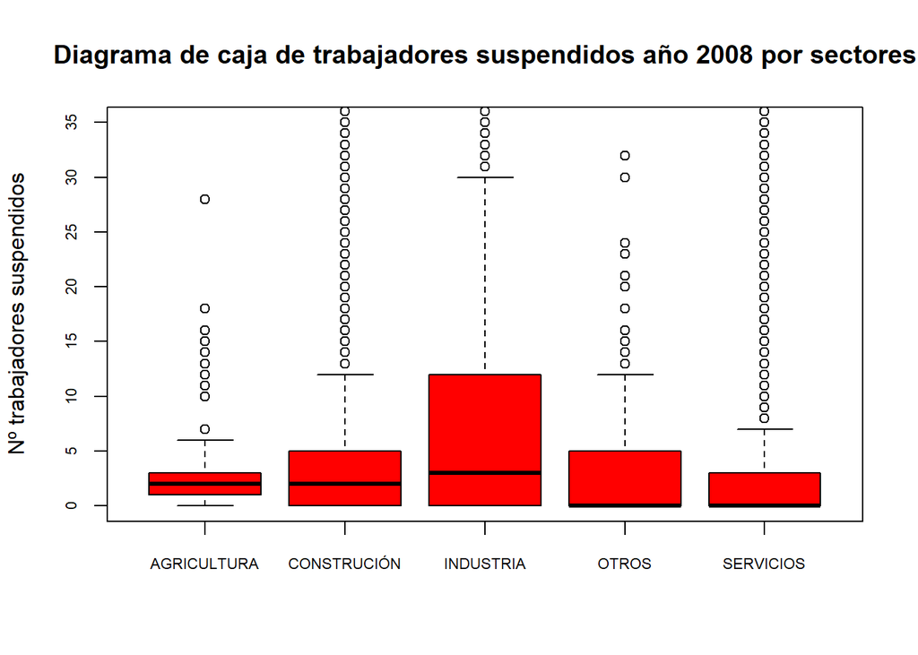

```r
boxplot(df_2008$TOTAL_TRAB_SUS~df_2008$SECTOR, main="Diagrama de caja de trabajadores suspendidos año 2008 por sectores", ylab="Nº trabajadores suspendidos", xlab="",col = "red", ylim=c(0,35), cex.axis = 0.7)
```

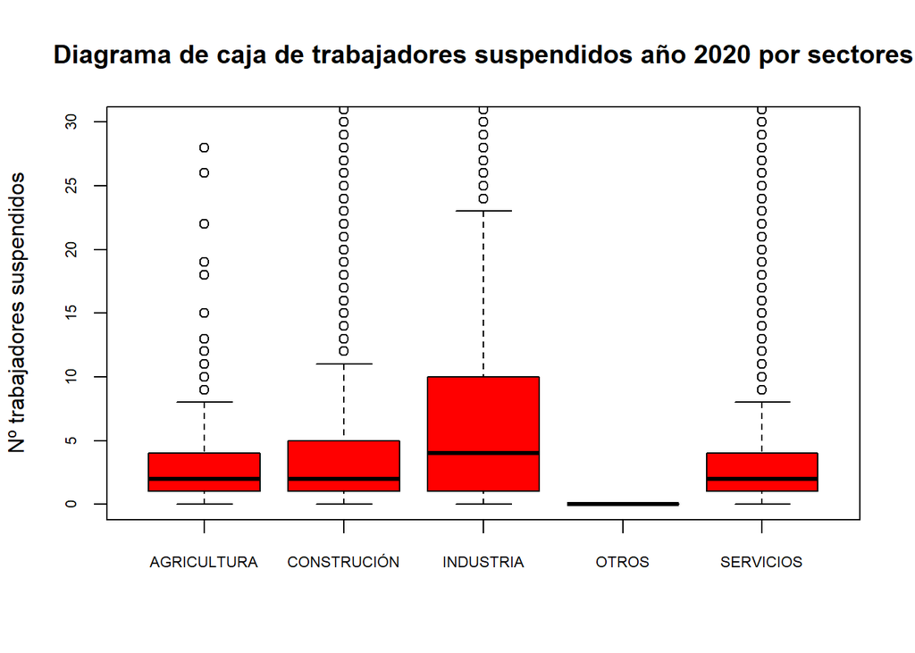

```r
boxplot(df_2020$TOTAL_TRAB_SUS~df_2020$SECTOR, main="Diagrama de caja de trabajadores suspendidos año 2020 por sectores", ylab="Nº trabajadores suspendidos", xlab="",col = "red", ylim=c(0,30), cex.axis = 0.7)
```

# Regresión Lineal.

### Buscamos la relación (nº trabajadores suspendidos) = a + b·(total trabajadores afectador por el ERTE).

```r
#trab_totales<- sum(colSums (df[ , 8:10]))
#trab_totales
regresion1 <- lm(df$TOTAL_TRAB_SUS ~ df$TOTAL_TRAB, df)
regresion1
```

```
##
## Call:
## lm(formula = df$TOTAL_TRAB_SUS ~ df$TOTAL_TRAB, data = df)
##
## Coefficients:
##   (Intercept)  df$TOTAL_TRAB
##       -1.6442         0.9223
```

```r
summary(regresion1)
```

```
##
## Call:
## lm(formula = df$TOTAL_TRAB_SUS ~ df$TOTAL_TRAB, data = df)
##
## Residuals:
##     Min      1Q  Median      3Q     Max
## -3835.1     1.7     1.8     2.0   931.3
##
## Coefficients:
##                 Estimate Std. Error t value Pr(>|t|)
## (Intercept)   -1.6441611  0.0717127  -22.93   <2e-16 ***
## df$TOTAL_TRAB  0.9222964  0.0008332 1106.92   <2e-16 ***
## ---
## Signif. codes:  0 '***' 0.001 '**' 0.01 '*' 0.05 '.' 0.1 ' ' 1
##
## Residual standard error: 22.74 on 101867 degrees of freedom
## Multiple R-squared:  0.9232, Adjusted R-squared:  0.9232
## F-statistic: 1.225e+06 on 1 and 101867 DF,  p-value: < 2.2e-16
```

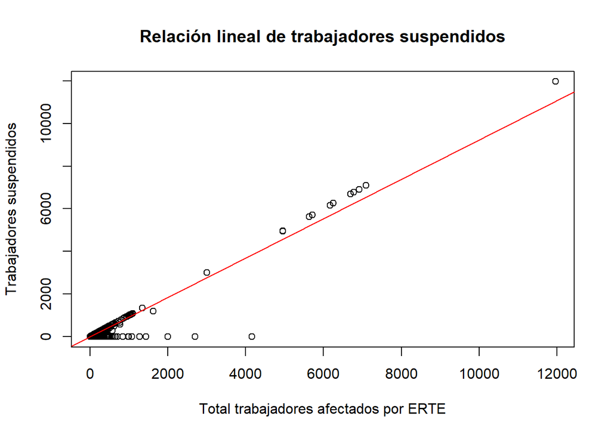

```r
plot(df$TOTAL_TRAB, df$TOTAL_TRAB_SUS, xlab='Total trabajadores afectados por ERTE', ylab='Trabajadores suspendidos', main = "Relación lineal de trabajadores suspendidos")
abline(regresion1, col = "red")
```

### Buscamos la relación (nº trabajadores extinguidos) = a + b·(total trabajadores afectador por el ERTE).

```r
regresion2<- lm(df$TOTAL_TRAB_EXT ~ df$TOTAL_TRAB, df)
regresion2
```

```
##
## Call:
## lm(formula = df$TOTAL_TRAB_EXT ~ df$TOTAL_TRAB, data = df)
##
## Coefficients:
##   (Intercept)  df$TOTAL_TRAB
##       0.69939        0.06292
```

```r
summary(regresion2)
```

```
##
## Call:
## lm(formula = df$TOTAL_TRAB_EXT ~ df$TOTAL_TRAB, data = df)
##
## Residuals:
##    Min     1Q Median     3Q    Max
## -753.4   -1.1   -0.9   -0.8 3897.6
##
## Coefficients:
##                Estimate Std. Error t value Pr(>|t|)
## (Intercept)   0.6993948  0.0654633   10.68   <2e-16 ***
## df$TOTAL_TRAB 0.0629171  0.0007606   82.72   <2e-16 ***
## ---
## Signif. codes:  0 '***' 0.001 '**' 0.01 '*' 0.05 '.' 0.1 ' ' 1
##
## Residual standard error: 20.76 on 101867 degrees of freedom
## Multiple R-squared:  0.06294,    Adjusted R-squared:  0.06294
## F-statistic:  6843 on 1 and 101867 DF,  p-value: < 2.2e-16
```

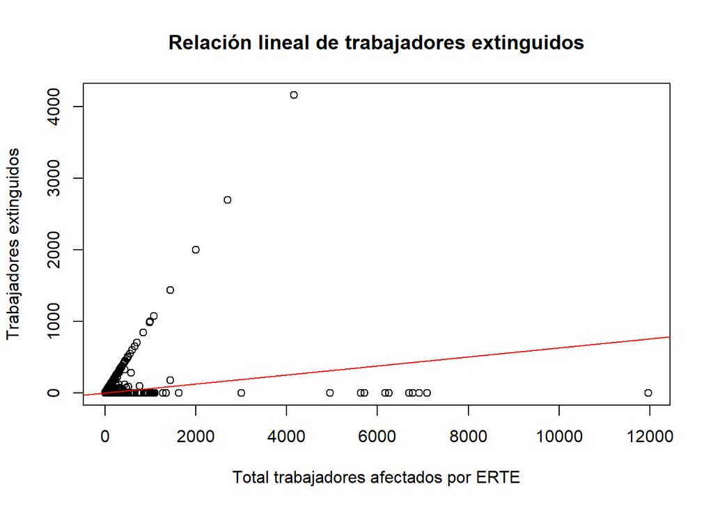

```r
plot(df$TOTAL_TRAB, df$TOTAL_TRAB_EXT, xlab='Total trabajadores afectados por ERTE', ylab='Trabajadores extinguidos', main = "Relación lineal de trabajadores extinguidos")
abline(regresion2, col = "red")
```

### Buscamos la relación (nº trabajadores reducidos) = a + b·(total trabajadores afectador por el ERTE).

```r
regresion3 <- lm(df$TOTAL_TRAB_RED ~ df$TOTAL_TRAB, df)
regresion3
```

```
##
## Call:
## lm(formula = df$TOTAL_TRAB_RED ~ df$TOTAL_TRAB, data = df)
##
## Coefficients:
##   (Intercept)  df$TOTAL_TRAB
##       0.94477        0.01479
```

```r
summary(regresion3)
```

```
##
## Call:
## lm(formula = df$TOTAL_TRAB_RED ~ df$TOTAL_TRAB, data = df)
##
## Residuals:
##     Min      1Q  Median      3Q     Max
## -177.85   -1.02   -0.97   -0.96 1260.13
##
## Coefficients:
##                Estimate Std. Error t value Pr(>|t|)
## (Intercept)   0.9447662  0.0303231   31.16   <2e-16 ***
## df$TOTAL_TRAB 0.0147865  0.0003523   41.97   <2e-16 ***
## ---
## Signif. codes:  0 '***' 0.001 '**' 0.01 '*' 0.05 '.' 0.1 ' ' 1
##
## Residual standard error: 9.614 on 101867 degrees of freedom
## Multiple R-squared:  0.017,  Adjusted R-squared:  0.01699
## F-statistic:  1761 on 1 and 101867 DF,  p-value: < 2.2e-16
```

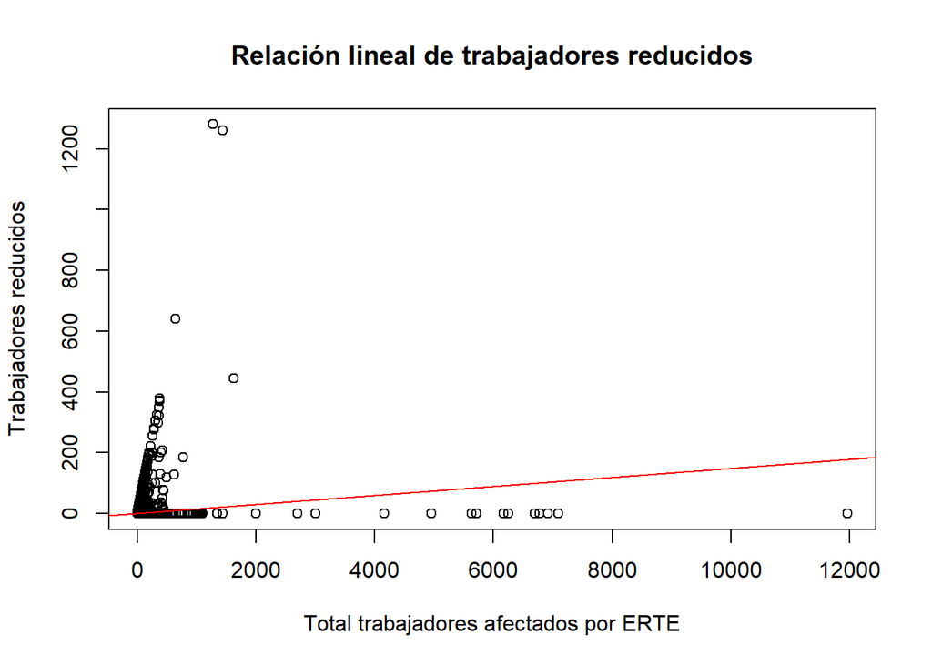

```r
plot(df$TOTAL_TRAB, df$TOTAL_TRAB_RED, xlab='Total trabajadores afectados por ERTE', ylab='Trabajadores reducidos', main = "Relación lineal de trabajadores reducidos")
abline(regresion3, col = "red")
```